# People’s Bank of China release coverage

A bilingual, complete-index dashboard built with readPBOC and ggplot2

23 July 2026

This dashboard calls `readPBOC` to traverse every page reported by every configured Chinese and English release index. Its charts and searchable inventory use every indexed release. The frozen snapshot provides a reproducible view, and the refresh parameters rebuild it directly from the official PBOC websites.

1,432Unique releases

6Official release feeds

108Index pages traversed

2001–2026Publication span

Snapshot retrieved at 2026-07-23 18:39 AEST. It spans 17 April 2001 through 15 July 2026.

## Release history

### Annual coverage

Every annual bar uses the complete bilingual release index.

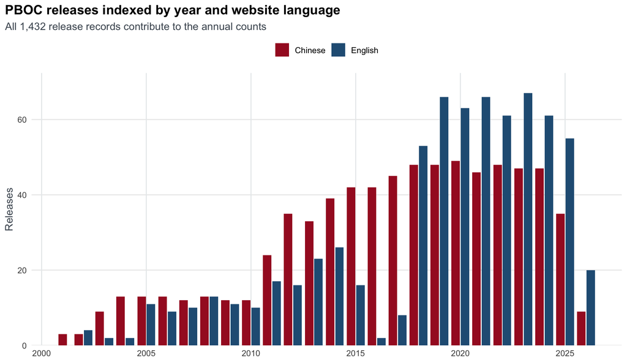

```r
ggplot(
  annual_counts,
  aes(x = year, y = releases, fill = language_label)
) +
  geom_col(position = position_dodge2(width = 0.84, preserve = "single")) +
  scale_fill_manual(values = language_colours) +
  scale_x_continuous(
    breaks = seq(
      floor(min(annual_counts$year) / 5) * 5,
      max(annual_counts$year),
      by = 5
    )
  ) +
  scale_y_continuous(labels = comma, expand = expansion(mult = c(0, 0.08))) +
  labs(
    title = "PBOC releases indexed by year and website language",
    subtitle = paste(
      "All",
      comma(nrow(release_index)),
      "release records contribute to the annual counts"
    ),
    x = NULL,
    y = "Releases"
  ) +
  theme_pboc()
```

### Cumulative archive

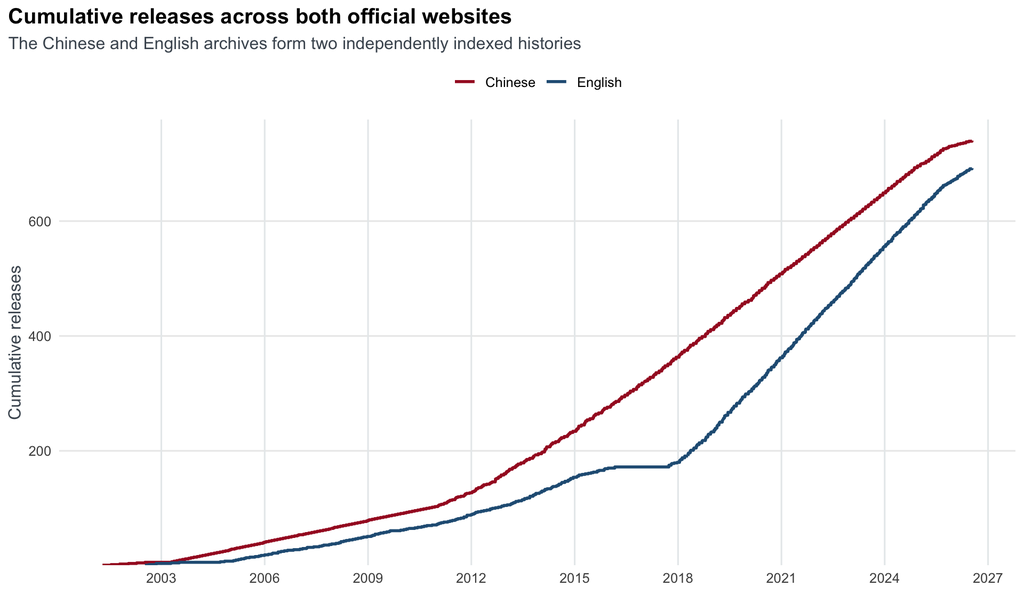

```r
cumulative <- release_index |>
  arrange(language_label, published_at, release_id) |>
  group_by(language_label) |>
  mutate(releases = row_number()) |>
  ungroup()

ggplot(
  cumulative,
  aes(x = published_at, y = releases, colour = language_label)
) +
  geom_step(linewidth = 1) +
  scale_colour_manual(values = language_colours) +
  scale_x_date(date_breaks = "3 years", date_labels = "%Y") +
  scale_y_continuous(labels = comma, expand = expansion(mult = c(0, 0.05))) +
  labs(
    title = "Cumulative releases across both official websites",
    subtitle = "The Chinese and English archives form two independently indexed histories",
    x = NULL,
    y = "Cumulative releases"
  ) +
  theme_pboc()
```

### Monthly cadence

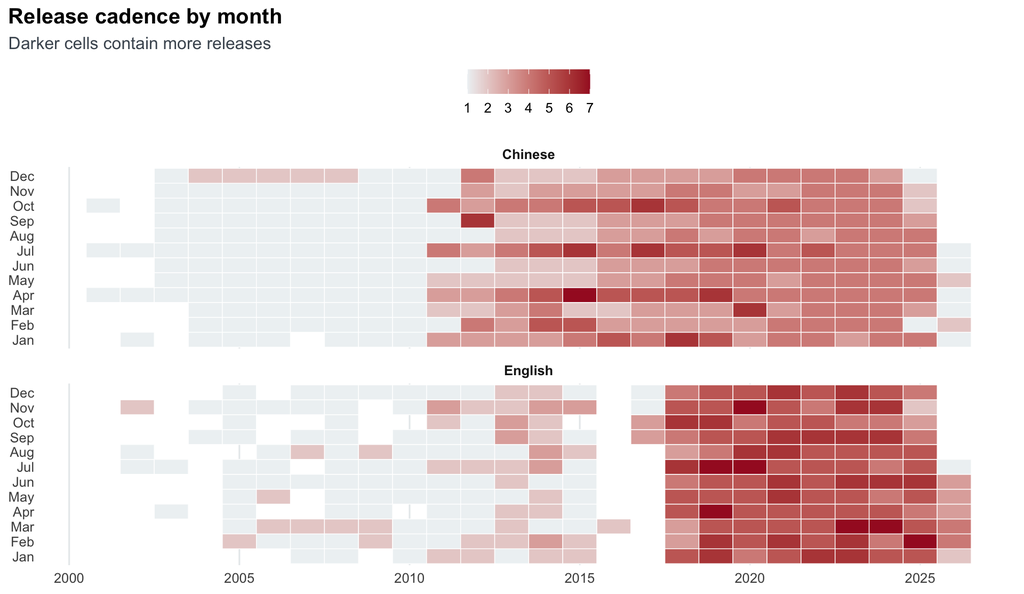

```r
ggplot(
  monthly_counts,
  aes(x = year, y = month, fill = releases)
) +
  geom_tile(colour = "white", linewidth = 0.25) +
  facet_wrap(~ language_label, ncol = 1) +
  scale_fill_gradient(low = "#EEF2F4", high = "#A61B29") +
  scale_x_continuous(
    breaks = seq(
      floor(min(monthly_counts$year) / 5) * 5,
      max(monthly_counts$year),
      by = 5
    )
  ) +
  labs(
    title = "Release cadence by month",
    subtitle = "Darker cells contain more releases",
    x = NULL,
    y = NULL,
    fill = "Releases"
  ) +
  theme_pboc() +
  theme(panel.grid = element_blank())
```

## Feed coverage

### Releases by feed

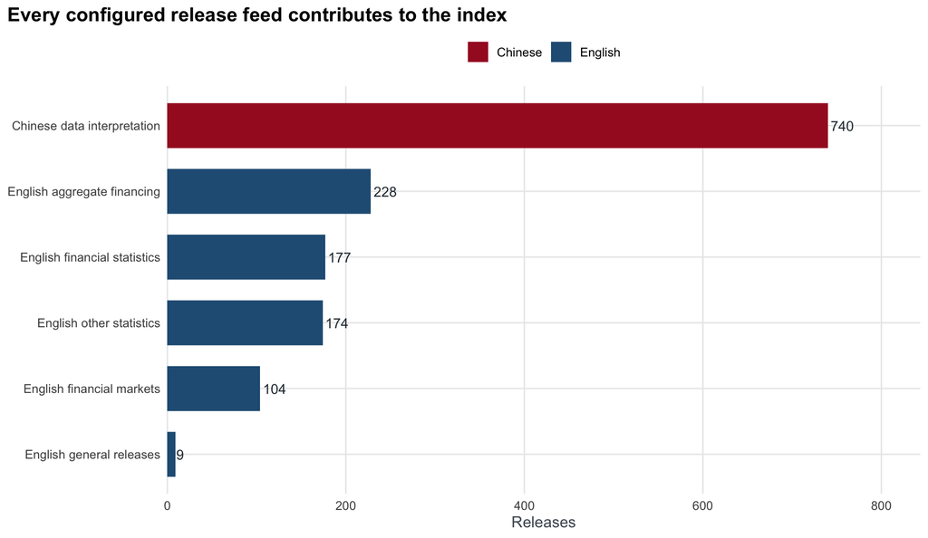

```r
ggplot(
  category_counts,
  aes(
    x = reorder(feed, releases),
    y = releases,
    fill = language_label
  )
) +
  geom_col(width = 0.68) +
  geom_text(
    aes(label = comma(releases)),
    hjust = -0.12,
    colour = "#28343D",
    size = 3.8
  ) +
  coord_flip(clip = "off") +
  scale_fill_manual(values = language_colours) +
  scale_y_continuous(
    labels = comma,
    expand = expansion(mult = c(0, 0.14))
  ) +
  labs(
    title = "Every configured release feed contributes to the index",
    x = NULL,
    y = "Releases"
  ) +
  theme_pboc()
```

### Feed history

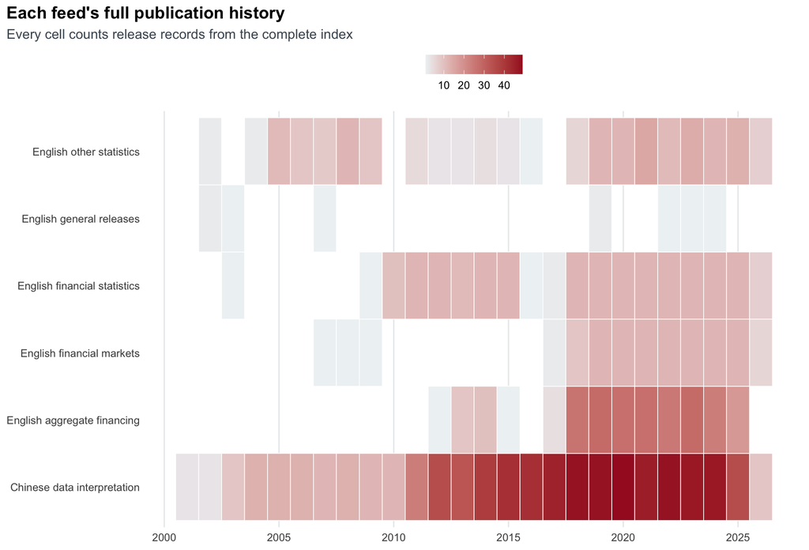

```r
ggplot(
  heatmap_counts,
  aes(x = year, y = feed, fill = releases)
) +
  geom_tile(colour = "white", linewidth = 0.3) +
  scale_fill_gradient(low = "#EEF2F4", high = "#A61B29") +
  scale_x_continuous(
    breaks = seq(
      floor(min(heatmap_counts$year) / 5) * 5,
      max(heatmap_counts$year),
      by = 5
    )
  ) +
  labs(
    title = "Each feed's full publication history",
    subtitle = "Every cell counts release records from the complete index",
    x = NULL,
    y = NULL,
    fill = "Releases"
  ) +
  theme_pboc() +
  theme(panel.grid = element_blank())
```

### Feed totals

```r
knitr::kable(
  feed_summary |>
    arrange(language_label, desc(releases)) |>
    transmute(
      Language = language_label,
      Feed = feed,
      Releases = releases,
      `Index pages` = index_pages,
      Earliest = format(earliest, "%Y-%m-%d"),
      Latest = format(latest, "%Y-%m-%d")
    ),
  format.args = list(big.mark = ","),
  align = c("l", "l", "r", "r", "l", "l")
)
```

| Language | Feed | Releases | Index pages | Earliest | Latest |
| --- | --- | --- | --- | --- | --- |
| Chinese | Chinese data interpretation | 740 | 37 | 2001-04-17 | 2026-07-15 |
| English | English aggregate financing | 228 | 23 | 2012-02-17 | 2025-09-12 |
| English | English financial statistics | 177 | 18 | 2003-04-14 | 2026-07-15 |
| English | English other statistics | 174 | 18 | 2002-07-11 | 2026-06-18 |
| English | English financial markets | 104 | 11 | 2007-03-22 | 2026-06-22 |
| English | English general releases | 9 | 1 | 2002-11-07 | 2024-09-13 |

## Coverage audit

### Metadata completeness

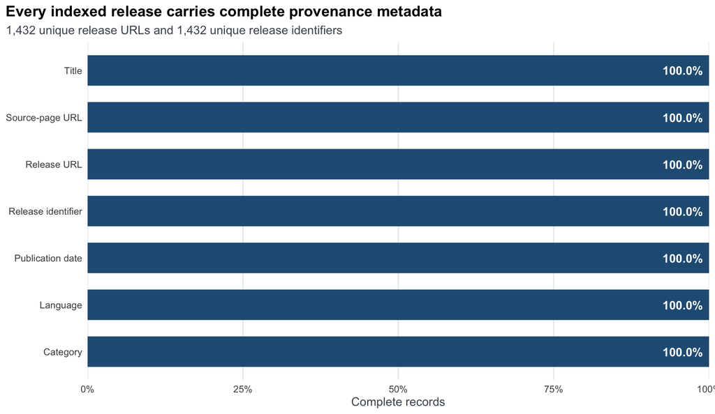

```r
ggplot(
  completeness,
  aes(x = reorder(field, share), y = share)
) +
  geom_col(fill = "#265D84", width = 0.65) +
  geom_text(
    aes(label = percent(share, accuracy = 0.1)),
    hjust = 1.15,
    colour = "white",
    fontface = "bold"
  ) +
  coord_flip() +
  scale_y_continuous(
    labels = percent,
    limits = c(0, 1),
    expand = expansion(mult = c(0, 0))
  ) +
  labs(
    title = "Every indexed release carries complete provenance metadata",
    subtitle = paste(
      comma(nrow(release_index)),
      "unique release URLs and",
      comma(n_distinct(release_index$release_id)),
      "unique release identifiers"
    ),
    x = NULL,
    y = "Complete records"
  ) +
  theme_pboc() +
  theme(legend.position = "none")
```

### Text extraction

`pboc_read_release()` retrieves article text, paragraph boundaries, and attachment links. The audit exercises the earliest and latest release in every configured feed, covering both current and legacy page structures.

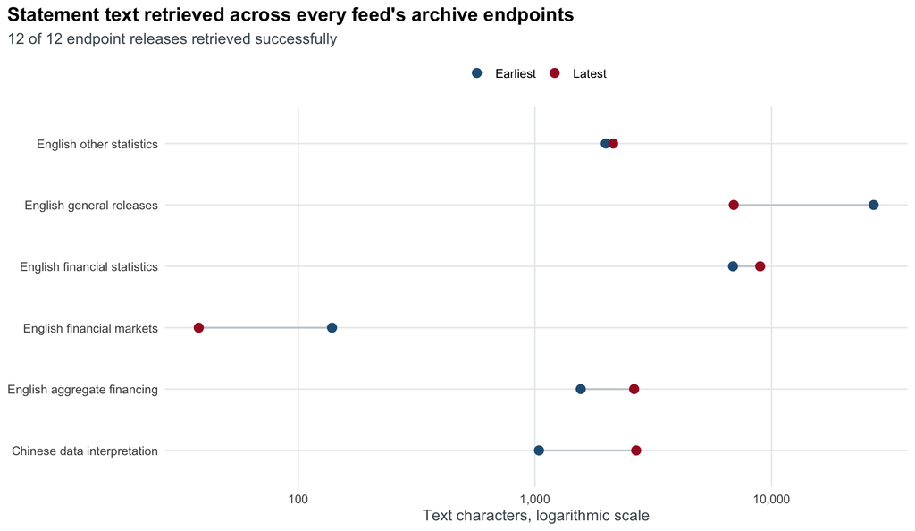

```r
ggplot(
  text_audit,
  aes(
    x = feed,
    y = text_characters,
    colour = endpoint,
    group = feed
  )
) +
  geom_line(colour = "#C9CED3", linewidth = 0.7) +
  geom_point(size = 3) +
  coord_flip() +
  scale_colour_manual(
    values = c(Earliest = "#265D84", Latest = "#A61B29")
  ) +
  scale_y_log10(labels = comma) +
  labs(
    title = "Statement text retrieved across every feed's archive endpoints",
    subtitle = paste(
      sum(text_audit$status == "retrieved"),
      "of",
      nrow(text_audit),
      "endpoint releases retrieved successfully"
    ),
    x = NULL,
    y = "Text characters, logarithmic scale"
  ) +
  theme_pboc()
```

```r
knitr::kable(
  text_audit |>
    arrange(feed, endpoint) |>
    transmute(
      Feed = feed,
      Endpoint = endpoint,
      Date = format(published_at, "%Y-%m-%d"),
      Status = status,
      `Text characters` = text_characters,
      Paragraphs = paragraphs,
      Attachments = attachments
    ),
  format.args = list(big.mark = ","),
  align = c("l", "l", "l", "l", "r", "r", "r")
)
```

| Feed | Endpoint | Date | Status | Text characters | Paragraphs | Attachments |
| --- | --- | --- | --- | --- | --- | --- |
| Chinese data interpretation | Earliest | 2001-04-17 | retrieved | 1,041 | 9 | 0 |
| Chinese data interpretation | Latest | 2026-07-15 | retrieved | 2,679 | 67 | 0 |
| English aggregate financing | Earliest | 2012-02-17 | retrieved | 1,563 | 4 | 0 |
| English aggregate financing | Latest | 2025-09-12 | retrieved | 2,627 | 4 | 0 |
| English financial markets | Earliest | 2007-03-22 | retrieved | 139 | 2 | 1 |
| English financial markets | Latest | 2026-06-22 | retrieved | 38 | 1 | 1 |
| English financial statistics | Earliest | 2003-04-14 | retrieved | 6,871 | 53 | 0 |
| English financial statistics | Latest | 2026-07-15 | retrieved | 8,952 | 70 | 0 |
| English general releases | Earliest | 2002-11-07 | retrieved | 27,009 | 126 | 0 |
| English general releases | Latest | 2024-09-13 | retrieved | 6,923 | 14 | 0 |
| English other statistics | Earliest | 2002-07-11 | retrieved | 1,993 | 80 | 0 |
| English other statistics | Latest | 2026-06-18 | retrieved | 2,142 | 44 | 0 |

## Every release

The table contains every release in the snapshot. Search and column filters provide direct access to titles, dates, languages, feeds, identifiers, official release URLs, and the exact index page where each record was discovered.

| Date | Language | Feed | Title | Release ID | Official release URL | Official index page |
| --- | --- | --- | --- | --- | --- | --- |
| 2026-07-15 | English | English financial statistics | Financial Statistics Report (H1 2026) | 2026071615101246166 | https://www.pbc.gov.cn/en/3688247/3688978/3709137/2026071615101246166/index.html | https://www.pbc.gov.cn/en/3688247/3688978/3709137/index.html |
| 2026-07-15 | Chinese | Chinese data interpretation | 2026年上半年金融统计数据报告 | 2026071515025183948 | https://www.pbc.gov.cn/diaochatongjisi/116219/116225/2026071515025183948/index.html | https://www.pbc.gov.cn/diaochatongjisi/116219/116225/index.html |
| 2026-06-22 | English | English financial markets | Financial Market Report (May 2026) | 2026062614041449643 | https://www.pbc.gov.cn/en/3688247/3688978/3709134/2026062614041449643/index.html | https://www.pbc.gov.cn/en/3688247/3688978/3709134/index.html |
| 2026-06-18 | English | English other statistics | Total assets of financial institutions reached 556.3 trillion yuan at end-Q1 2026 | 2026062914000064637 | https://www.pbc.gov.cn/en/3688247/3688978/3709143/2026062914000064637/index.html | https://www.pbc.gov.cn/en/3688247/3688978/3709143/index.html |
| 2026-06-12 | English | English financial statistics | Financial Statistics Report (May 2026) | 2026061615365661496 | https://www.pbc.gov.cn/en/3688247/3688978/3709137/2026061615365661496/index.html | https://www.pbc.gov.cn/en/3688247/3688978/3709137/index.html |
| 2026-06-12 | Chinese | Chinese data interpretation | 2026年5月金融统计数据报告 | 2026061217051611931 | https://www.pbc.gov.cn/diaochatongjisi/116219/116225/2026061217051611931/index.html | https://www.pbc.gov.cn/diaochatongjisi/116219/116225/index.html |
| 2026-05-22 | English | English financial markets | Financial Market Report (April 2026) | 2026052716543840338 | https://www.pbc.gov.cn/en/3688247/3688978/3709134/2026052716543840338/index.html | https://www.pbc.gov.cn/en/3688247/3688978/3709134/index.html |
| 2026-05-15 | English | English other statistics | Payment System Report (Q1 2026) | 2026071014073659154 | https://www.pbc.gov.cn/en/3688247/3688978/3709143/2026071014073659154/index.html | https://www.pbc.gov.cn/en/3688247/3688978/3709143/index.html |
| 2026-05-14 | English | English financial statistics | Financial Statistics Report (April 2026) | 2026051516292728050 | https://www.pbc.gov.cn/en/3688247/3688978/3709137/2026051516292728050/index.html | https://www.pbc.gov.cn/en/3688247/3688978/3709137/index.html |
| 2026-05-14 | Chinese | Chinese data interpretation | 2026年4月金融统计数据报告 | 2026051417030520490 | https://www.pbc.gov.cn/diaochatongjisi/116219/116225/2026051417030520490/index.html | https://www.pbc.gov.cn/diaochatongjisi/116219/116225/index.html |

[output cut: 1422 more lines]

## Rebuild the evidence

Render the frozen snapshot:

```r
rmarkdown::render(
  "inst/examples/pboc-release-coverage-dashboard.Rmd"
)
```

Refresh every index page and both endpoints of every release feed, then render:

```r
rmarkdown::render(
  "inst/examples/pboc-release-coverage-dashboard.Rmd",
  params = list(
    refresh_index = TRUE,
    refresh_text_audit = TRUE
  )
)
```

The refresh path calls these public package functions:

```r
all_releases <- pboc_releases(
  language = "both",
  pages = "all"
)

one_statement <- pboc_read_release(all_releases[1, ])
```